# Lab 1

# Open Response

For this exercise, use the **diamonds** dataset in the tidyverse. Use `?diamonds` to get more information about the dataset.

## Step 1: Select 1 numeric variable and 2 categorical variables. Create a graphic using `geom_boxplot()` and `facet_wrap` to illustrate the empirical distributions of the sample.

```r
#--> Get an idea of what's in the dataset
head(diamonds)
```

```
## # A tibble: 6 x 10
##   carat cut       color clarity depth table price     x     y     z
##   <dbl> <ord>     <ord> <ord>   <dbl> <dbl> <int> <dbl> <dbl> <dbl>
## 1 0.23  Ideal     E     SI2      61.5    55   326  3.95  3.98  2.43
## 2 0.21  Premium   E     SI1      59.8    61   326  3.89  3.84  2.31
## 3 0.23  Good      E     VS1      56.9    65   327  4.05  4.07  2.31
## 4 0.290 Premium   I     VS2      62.4    58   334  4.2   4.23  2.63
## 5 0.31  Good      J     SI2      63.3    58   335  4.34  4.35  2.75
## 6 0.24  Very Good J     VVS2     62.8    57   336  3.94  3.96  2.48
```

Categorical:  
- cut - color - clarity

Numerical:  
-carat -depth -table -price -x -y -z

Now that we know what’s in the data set, we can start poking around. We will most likely be interested in how all of the variables factor into the price of the diamond. Price will be our numeric; we’ll try cut and color as categorical variables.

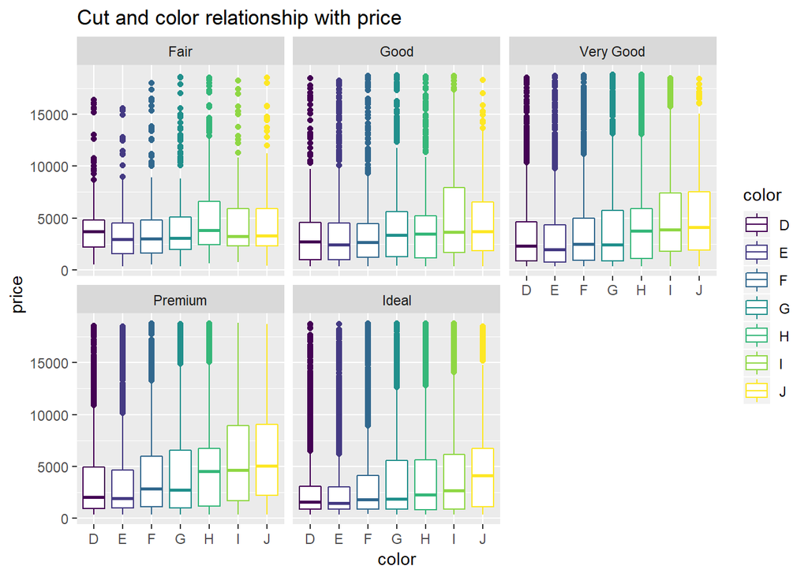

```r
#--> Graph relating price, cut, and color
ggplot(data = diamonds) +
  geom_boxplot(mapping = aes(x = color, y = price, color = color)) +
  facet_wrap(~ cut) +
  ggtitle("Cut and color relationship with price")
```

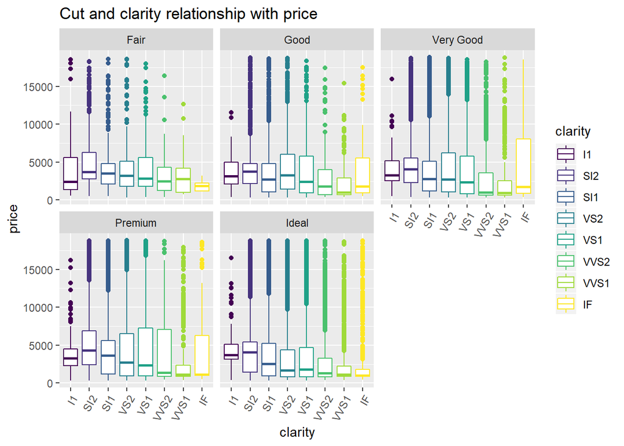

```r
#--> Note:
# Turns out this is very nearly identical to Dr. Mario's. Did not intend for that to happen. For good measure, here is another visualization that is different from Dr. Mario's.
ggplot(data = diamonds) +
  geom_boxplot(mapping = aes(x = clarity, y = price, color = clarity)) +
  facet_wrap(~ cut) +
  theme(axis.text.x = element_text(angle=60, hjust=1)) + # Make the x labels so they are not running into each other
  ggtitle("Cut and clarity relationship with price")
```

## Step 2: Choose 2 numeric variables and 2 categorical variables and creatively illustrate the relationship between all the variables.

We’re still interested in price, color, and cut. Let’s also add in carat.

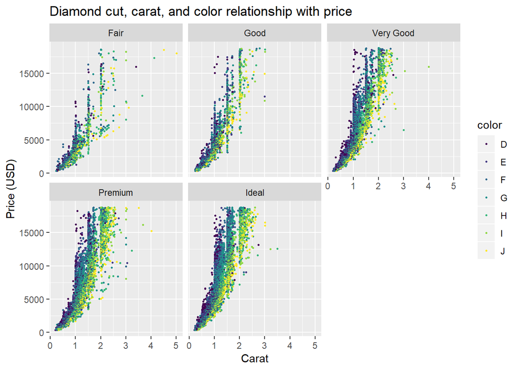

```r
#--> Imagining point plot object relating carat and price; color coded by color and faceted by cut.
ggplot(data = diamonds) +
  geom_point(mapping = aes(x = carat, y = price, color = color), size = 0.6) +
  facet_wrap(~ cut) +
  ggtitle("Diamond cut, carat, and color relationship with price") +
  xlab("Carat") +
  ylab("Price (USD)")
```

This lab completed by Coleman Breen.